# ggplot2_CH2

### 2.4.1 Exercises

1. Experiment with the color, shape and size aesthetics. What happens when you map them to continous values? What about categorical values? What happens when you use more than one aesthetic in a plot?
1. Map color, shape, size to continuous values; Use more than one aesthetic in a plot

```r
ggplot(mpg, aes(displ, hwy, aes(color=cty, shape=cty, size=hwy)))+
  geom_point()
```

[output not shown]

```r
# Nothing gets mapped

ggplot(mpg, aes(displ, hwy))+
  geom_point(aes(color=cty, shape=cty, size=hwy))
```

```
## Error: A continuous variable can not be mapped to shape
```

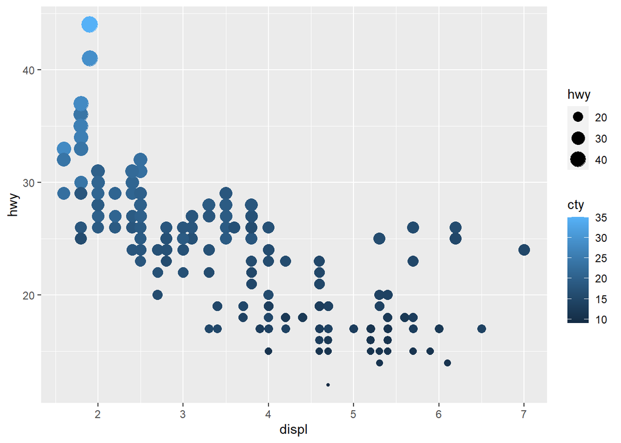

```r
# Error: A continuous variable can not be mapped to shape


##### EUIQVALENT #####
ggplot(mpg, aes(displ, hwy))+
  geom_point(aes(color=cty, size=hwy))
```

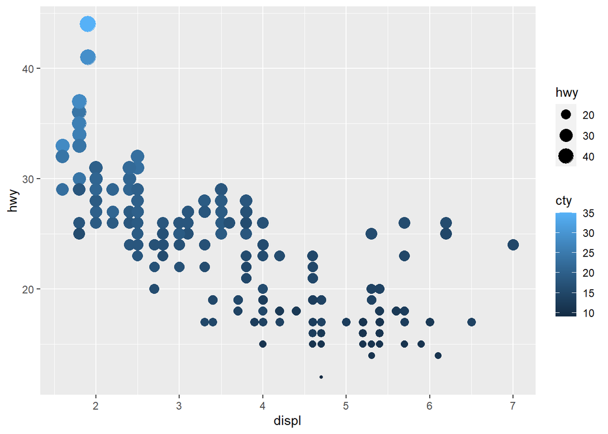

```r
ggplot(mpg, aes(displ, hwy))+
  geom_point(aes(color=cty, size=hwy))
```

```r
# No error, able to map but not very informative
```

2. Map color, shape, size to categorical values

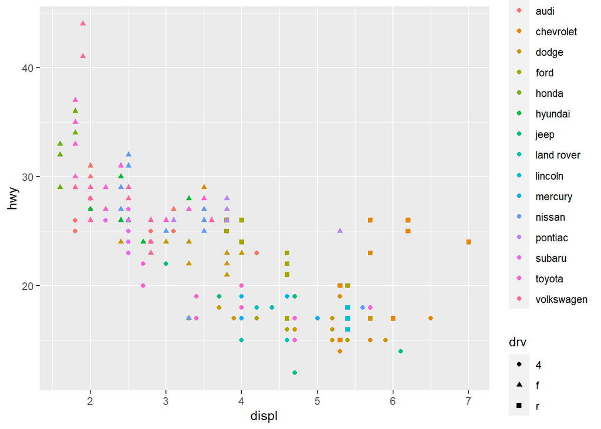

```r
ggplot(mpg, aes(displ, hwy, color=manufacturer, shape=drv))+
  geom_point()
```

2. What happens if you map a continuous variable to shape? Why? What happens if you map `trans` to shape? Why?

Map to a continuous variable to shape will result in an error because shape is discrete not continuous.

Map `trans` to shape

```
## Warning: Removed 96 rows containing missing values (geom_point).
```

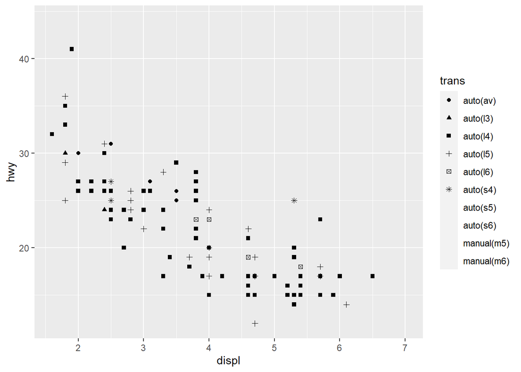

```r
ggplot(mpg, aes(displ, hwy, shape=trans))+
  geom_point()
```

```r
unique(mpg$trans)
```

```
##  [1] "auto(l5)"   "manual(m5)" "manual(m6)" "auto(av)"   "auto(s6)"
##  [6] "auto(l4)"   "auto(l3)"   "auto(l6)"   "auto(s5)"   "auto(s4)"
```

Get warning messages because the shape palette can deal with a maximum of 6 discrete values and `trans` has 10 distinct values.

3. How is drive train related to fuel economy? How is drive train related to engine size and class?

Drive Train v.s. Engine Size v.s. Class

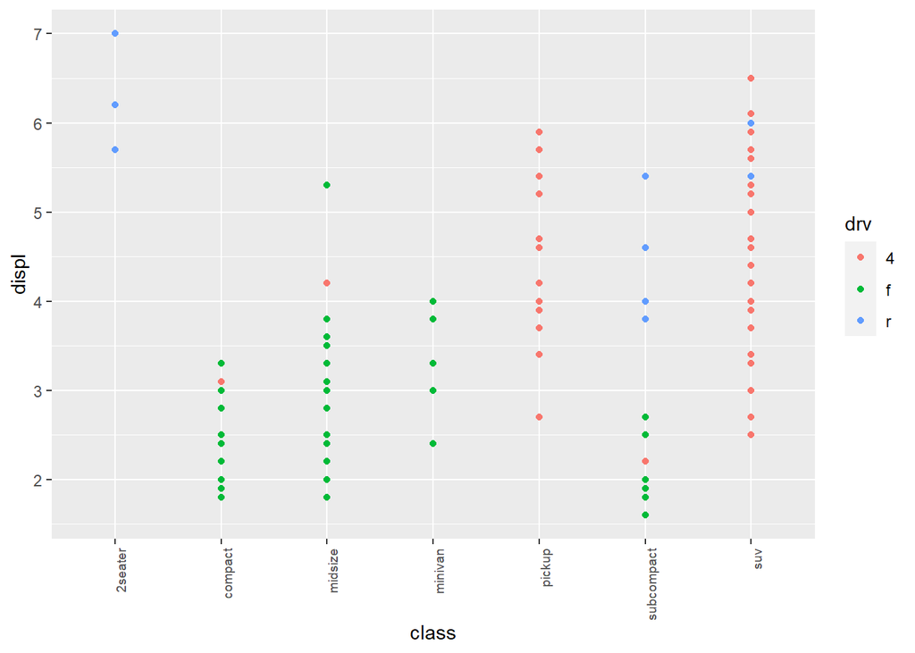

```r
ggplot(mpg, aes(class, displ, color=drv))+
  geom_point()+
  theme(axis.text.x=element_text(angle=90, hjust=1, size=7))
```